# TerraclimateR

The terraclimate data set[^1] provides data on 14 climatic variables through time since 1958 at ~4km resolution in space and monthly resolution in time. TerraclimateR is a lightweight package that implements a single function (`get_terraclim`) to access these data and import them directly into R in long format.

### General information:

https://www.climatologylab.org/terraclimate.html

### Usage

```r
library(TerraclimateR)
suppressPackageStartupMessages(library(tidyverse))
```

Input data (`df`) is required in the following format: a data.frame (or matrix) containing at least three variables (columns): a (unique) identifier, latitude, and longitude:

```r
df <- tidyr::tribble(
  ~id,            ~lat,       ~lon,
  "Vilcabamba",    -4.260641, -79.22274,
  "Paracas",      -13.833881, -76.25046,
  "Puerto Viejo",   9.656562, -82.75600,
  "Trinidad",      21.808230, -79.98102,
  "Cartagena",     10.172151, -75.74658
)
```

To retrieve climatic data for these observations (rows), a character containing selected terraclimate variables is passed to the `clim_vars` argument (e.g. `c("aet", "def")`). The follwing variables are available:

### Available terraclimate variables:

| Code | Variable | Detail | Unit |
| --- | --- | --- | --- |
| **aet** | Actual Evapotranspiration | monthly total | $mm$ |
| **def** | Climate Water Deficit | monthly total | $mm$ |
| **pet** | Potential evapotranspiration | monthly total | $mm$ |
| **ppt** | Precipitation | monthly total | $mm$ |
| **q** | Runoff | monthly total | $mm$ |
| **soil** | Soil Moisture | total column at end of month | $mm$ |
| **srad** | Downward surface shortwave radiation |  | $W/m^2$ |
| **swe** | Snow water equivalent | at end of month | $mm$ |
| **tmax** | Max Temperature | average for month | $C$ |
| **tmin** | Min Temperature | average for month | $C$ |
| **vap** | Vapor pressure | average for month | $kPa$ |
| **ws** | Wind speed | average for month | $m/s$ |
| **vpd** | Vapor Pressure Deficit | average for month | $kPa$ |
| **PDSI** | Palmer Drought Severity Index | at end of month | unitless |

To retrieve all of these variables, pass `climvars = "ALL"`.

**Example:**

Retrieving data for minimum temperature per month (*tmin*) and monthly precipitation (*ppt*):

```r
nc_df <- get_terraclim(df        = df,
                       id_var    = id,
                       lon_var   = lon,
                       lat_var   = lat,
                       clim_vars = c("tmin", "ppt"),
                       show_prog = TRUE,
                       conserve  = TRUE)
```

The column `id` is retained and still contains our sample identifiers. The column `year` contains values ranging from 1958, the start of the terraclimate data set, to the latest year for which data are available. `month` specifies the month, and `variable` indicates the terraclimate variable. `value` is the value of the respective variable at the given month in the given year at the given location. Because `conserve = TRUE` was set in the function call, all the columns of the initial data.frame are still present. If the data.frame contains a lot of variables and hundreds of observations, it is advisable to set `conserve = FALSE` since this results in a lot of redundant information and may slow down computation. Also, if column names *year*, *month*, *variable*, or *value* are in original data they will be renamed (e.g. *year* to *year.x* and *year.y*) to guarantee unique variable names. Returning the data in long format facilitates further processing in a *tidy* style (see [tidy data](https://cran.r-project.org/web/packages/tidyr/vignettes/tidy-data.html)).

```r
str(nc_df)
```

```
## 'data.frame':    7800 obs. of  7 variables:
##  $ id      : chr  "Cartagena" "Cartagena" "Cartagena" "Cartagena" ...
##  $ year    : int  2022 2022 2022 2022 2022 2022 2022 2022 2022 2022 ...
##  $ month   : Factor w/ 12 levels "Jan","Feb","Mar",..: 4 3 8 5 6 7 12 9 10 11 ...
##  $ variable: Factor w/ 2 levels "ppt","tmin": 1 1 1 1 1 1 1 1 1 1 ...
##  $ value   : num  200.5 4.6 217 213.7 281.6 ...
##  $ lat     : num  10.2 10.2 10.2 10.2 10.2 ...
##  $ lon     : num  -75.7 -75.7 -75.7 -75.7 -75.7 ...
```

Retrieving data for only one year:

```r
get_terraclim(df        = df[1, ],
              id_var    = id,
              lon_var   = lon,
              lat_var   = lat,
              clim_vars = "ppt",
              show_prog = FALSE,
              conserve  = FALSE,
              year      = 2021)
```

```
##            id year month variable value
## 1  Vilcabamba 2021   Jan      ppt 102.9
## 2  Vilcabamba 2021   Feb      ppt 125.8
## 3  Vilcabamba 2021   Mar      ppt 336.7
## 4  Vilcabamba 2021   Apr      ppt 162.9
## 5  Vilcabamba 2021   May      ppt  54.8
## 6  Vilcabamba 2021   Jun      ppt  41.4
## 7  Vilcabamba 2021   Jul      ppt  20.3
## 8  Vilcabamba 2021   Aug      ppt  14.9
## 9  Vilcabamba 2021   Sep      ppt  20.8
## 10 Vilcabamba 2021   Oct      ppt 101.2
## 11 Vilcabamba 2021   Nov      ppt  72.3
## 12 Vilcabamba 2021   Dec      ppt  70.4
```

Retrieving data for a range of years:

```r
nc_df_1990_2000 <- get_terraclim(df        = df[1, ],
                                 id_var    = id,
                                 lon_var   = lon,
                                 lat_var   = lat,
                                 clim_vars = "ppt",
                                 show_prog = FALSE,
                                 conserve  = FALSE) %>%
  dplyr::filter(year %in% 1990:2000)

str(nc_df_1990_2000)
```

```
## 'data.frame':    132 obs. of  5 variables:
##  $ id      : chr  "Vilcabamba" "Vilcabamba" "Vilcabamba" "Vilcabamba" ...
##  $ year    : int  1990 1990 1990 1990 1990 1990 1990 1990 1990 1990 ...
##  $ month   : Factor w/ 12 levels "Jan","Feb","Mar",..: 1 2 3 4 5 6 7 8 9 10 ...
##  $ variable: Factor w/ 1 level "ppt": 1 1 1 1 1 1 1 1 1 1 ...
##  $ value   : num  82.3 129.9 115.9 107.6 44.9 ...
```

**NA Handling**

Missing values, i.e., NA’s, are not discarded by `get_terraclim`.

```r
incomplete_df <- tribble(
  ~id,            ~lat,       ~lon,
  "Vilcabamba",    -4.260641, -79.22274,
  NA,             -13.833881, -76.25046,
  "Puerto Viejo",         NA, -82.75600,
  "Trinidad",             NA,        NA,
  NA,                     NA,        NA
)
```

```r
incomplete_nc_df <- get_terraclim(df        = incomplete_df,
                                  id_var    = id,
                                  lon_var   = lon,
                                  lat_var   = lat,
                                  clim_vars = c("tmin"),
                                  conserve  = TRUE)

incomplete_nc_df %>% group_by(id, lat, lon) %>% reframe(data_length = n())
```

```
## # A tibble: 5 × 4
##   id              lat   lon data_length
##   <chr>         <dbl> <dbl>       <int>
## 1 NA.2         -13.8  -76.3         780
## 2 NA.5          NA     NA             1
## 3 Puerto Viejo  NA    -82.8           1
## 4 Trinidad      NA     NA             1
## 5 Vilcabamba    -4.26 -79.2         780
```

```r
summary(incomplete_nc_df)
```

```
##       id                 year          month     variable        value
##  Length:1563        Min.   :1958   Jan    :130   tmin:1560   Min.   :10.84
##  Class :character   1st Qu.:1974   Feb    :130   NA's:   3   1st Qu.:12.77
##  Mode  :character   Median :1990   Mar    :130               Median :13.51
##                     Mean   :1990   Apr    :130               Mean   :14.18
##                     3rd Qu.:2006   May    :130               3rd Qu.:14.88
##                     Max.   :2022   (Other):910               Max.   :21.47
##                     NA's   :3      NA's   :  3               NA's   :3
##       lat               lon
##  Min.   :-13.834   Min.   :-82.76
##  1st Qu.:-13.834   1st Qu.:-79.22
##  Median : -9.047   Median :-79.22
##  Mean   : -9.047   Mean   :-77.74
##  3rd Qu.: -4.261   3rd Qu.:-76.25
##  Max.   : -4.261   Max.   :-76.25
##  NA's   :3         NA's   :2
```

But exclusion of missing values is easy:

```r
incomplete_nc_df %>% drop_na() %>% summary()
```

```
##       id                 year          month     variable        value
##  Length:1560        Min.   :1958   Jan    :130   tmin:1560   Min.   :10.84
##  Class :character   1st Qu.:1974   Feb    :130               1st Qu.:12.77
##  Mode  :character   Median :1990   Mar    :130               Median :13.51
##                     Mean   :1990   Apr    :130               Mean   :14.18
##                     3rd Qu.:2006   May    :130               3rd Qu.:14.88
##                     Max.   :2022   Jun    :130               Max.   :21.47
##                                    (Other):780
##       lat               lon
##  Min.   :-13.834   Min.   :-79.22
##  1st Qu.:-13.834   1st Qu.:-79.22
##  Median : -9.047   Median :-77.74
##  Mean   : -9.047   Mean   :-77.74
##  3rd Qu.: -4.261   3rd Qu.:-76.25
##  Max.   : -4.261   Max.   :-76.25
##
```

### Integration into *Tidy* Workflow

**Transformations (Examples)**

```r
nc_df %>%
  group_by(id, month, variable) %>%
  summarise(monthly_mean = mean(value), .groups = "drop") %>%
  pivot_wider(values_from = monthly_mean, names_from = variable)
```

```
## # A tibble: 60 × 4
##    id        month     ppt  tmin
##    <chr>     <fct>   <dbl> <dbl>
##  1 Cartagena Jan     3.22   22.7
##  2 Cartagena Feb     0.778  22.9
##  3 Cartagena Mar     5.83   23.5
##  4 Cartagena Apr   103.     24.1
##  5 Cartagena May   160.     24.3
##  6 Cartagena Jun   160.     24.4
##  7 Cartagena Jul   117.     24.2
##  8 Cartagena Aug   184.     24.4
##  9 Cartagena Sep   149.     24.3
## 10 Cartagena Oct   240.     23.9
## # ℹ 50 more rows
```

```r
nc_df %>% group_by(id, year, variable) %>% summarize(yearly_sum = sum(value), .groups = "drop")
```

```
## # A tibble: 650 × 4
##    id         year variable yearly_sum
##    <chr>     <int> <fct>         <dbl>
##  1 Cartagena  1958 ppt           1105.
##  2 Cartagena  1958 tmin           280.
##  3 Cartagena  1959 ppt            960.
##  4 Cartagena  1959 tmin           270.
##  5 Cartagena  1960 ppt           1525.
##  6 Cartagena  1960 tmin           276.
##  7 Cartagena  1961 ppt           1256.
##  8 Cartagena  1961 tmin           273.
##  9 Cartagena  1962 ppt           1262
## 10 Cartagena  1962 tmin           270.
## # ℹ 640 more rows
```

**Visualisation**

It’s always convenient to plot the data in order to quickly identify incorrect coordinates, e.g., inverted values.

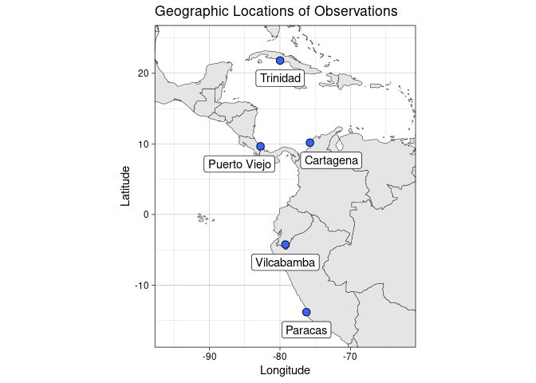

```r
world_map <- ggplot2::map_data("world")

dplyr::distinct(world_map, region) %>%
  ggplot() +
  geom_map(map = world_map, aes(map_id = region),
           fill = "gray90", color = "gray20", linewidth = 0.2) +
  geom_point(data = df, mapping = aes(lon, lat), fill = "#3366ff", size = 3, shape = 21) +
  geom_label(data = df %>% mutate(lon = case_when(id == "Puerto Viejo" ~ lon - 3,
                                                  id == "Cartagena" ~ lon + 3,
                                                  .default = lon)),
             mapping = aes(lon, lat - 2.5, label = id)) +
  expand_limits(x = c(min(df$lon) - 15, max(df$lon) + 15),
                y = c(min(df$lat) - 5, max(df$lat) + 5)) +
  coord_equal(expand = FALSE) +
  labs(x = "Longitude", y = "Latitude", title = "Geographic Locations of Observations") +
  theme_linedraw()
```

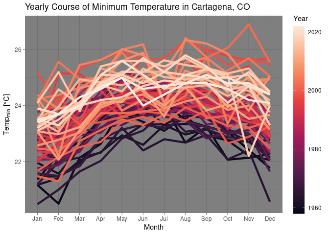

```r
nc_df %>% filter(id == "Cartagena" & variable == "tmin") %>%
ggplot() +
  aes(group = year, x = month, y = value, color = year) +
  geom_line(linewidth = 1.5) +
  scale_color_viridis_c(option = "rocket", name = "Year") +
  labs(x = "Month", y = expression(Temp[min]~"[°C]"), title = "Yearly Course of Minimum Temperature in Cartagena, CO") +
  theme_dark() +
  theme(legend.key.height = unit(0.8, "in"))
```

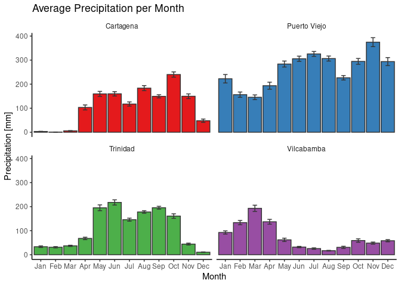

```r
nc_df %>%
  filter(id != "Paracas" & variable == "ppt") %>%
  group_by(id, variable, month) %>%
  summarise(monthly_mean = mean(value), se = sd(value)/sqrt(n()), .groups = "drop") %>%
  ggplot() +
  geom_col(aes(x = month, y = monthly_mean, fill = id), color = "gray20") +
  geom_errorbar(aes(x = month, ymin = monthly_mean - se, ymax = monthly_mean + se),
                color = "gray20", width = 0.3) +
  facet_wrap(. ~ id) +
  labs(x = "Month", y = "Precipitation [mm]", title = "Average Precipitation per Month") +
  scale_fill_brewer(palette = "Set1") +
  theme_classic() +
  theme(legend.position = "none", strip.background = element_blank())
```

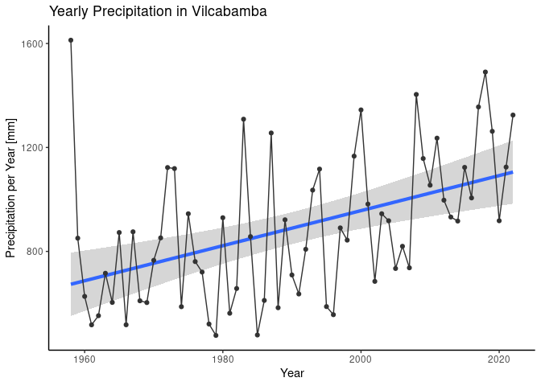

```r
nc_df %>%
  filter(variable == "ppt") %>%
  group_by(id, variable, year) %>%
  summarise(yearly_sum = sum(value), .groups = "drop") %>%
  filter(id == "Vilcabamba") %>%
  ggplot() +
  geom_smooth(aes(x = year, y = yearly_sum),
              color = "#3366ff", linewidth = 1.5, method = lm, formula = "y ~ x") +
  geom_point(aes(x = year, y = yearly_sum), color = "gray20") +
  geom_line(aes(x = year, y = yearly_sum), color = "gray20") +
  labs(x = "Year", y = "Precipitation per Year [mm]", title = "Yearly Precipitation in Vilcabamba") +
  theme_classic()
```

### Additional Information

There are currently two helper functions used internally in `TerraclimateR`. If you are interested you get further information:

```r
?TerraclimateR:::get_terraclim_single()

?TerraclimateR:::show_progress()
```

[^1]: Abatzoglou, J., Dobrowski, S., Parks, S. et al. TerraClimate, a high-resolution global dataset of monthly climate and climatic water balance from 1958–2015. Sci Data 5, 170191 (2018). https://doi.org/10.1038/sdata.2017.191